# 03_MappingExercise

K Nightingale

2023-07-05

This document contains one possible set of solutions to the mapping question posed below. There are many ways to code maps and approach problems like this, so what’s listed below is just one example.

# Mapping Practice - Heat Vulnerability and Tree Coverage

After a recent heat wave in Philadelphia, you’ve become interested in the city’s vulnerability to rising temperatures. You find a data resource that lists heat vulnerability by census tracts, and want to do an exploratory analysis to determine whether the presence of trees seems to be related to heat vulnerability. Generate a map incorporating these data sets and describe your findings. Can you tell much from your map? What might be some data manipulation you could try to have a more informative map? (Note: This isn’t a great question to address using these variables, because HVI incorporates vegetation into its calculation. But it works well for the sake of illustration.)

## Data Sources

- Heat vulnerability: https://opendataphilly.org/datasets/heat-vulnerability-by-census-tract/
- Tree inventory: https://opendataphilly.org/datasets/philadelphia-tree-inventory/

## Variable Descriptions

- Heat Sensitivity Index (HSI) - Sociodemographic and health factors that influence heat vulnerability. Incorporates percent of population over 65, percent of population over 25 without a high school diploma, percent of limited English-speaking households, percent of population below the federal poverty level, percent of population identifying as non-white, and percent of population over 65 and living alone, as well as the percent of adults diagnosed with asthma, COPD, CHD, diabetes, obesity, and hypertension.
- Heat Exposure Index (HEI) - Environmental factors that influence heat vulnerability. Incorporates land surface temperature, night land surface temperature, reflectivity, buildings, vegetation, and plant health.
- Heat Vulnerability Index (HVI) - Combines aspects of the HSI and HEI to indicate the population’s exposure and sensitivity to heat.

## Analysis

```r
#Heat data
url_heat <- "https://opendata.arcgis.com/api/v3/datasets/ee1f9ce6aa6f41f08fcdfa5101f203d7_0/downloads/data?format=shp&spatialRefId=4326&where=1%3D1"

#download zipfile and unzip
temp = tempfile()
temp2 = tempfile()
download.file(url_heat, temp, mode='wb')
unzip(zipfile=temp, exdir=temp2)

# Read the shapefiles
sf.heat <- read_sf(temp2)

#Tree data
url_tree <- "https://opendata.arcgis.com/api/v3/datasets/5abe042f2927486891c049cf064338cb_0/downloads/data?format=shp&spatialRefId=4326&where=1%3D1"

#download zipfile and unzip
temp = tempfile()
temp2 = tempfile()
download.file(url_tree, temp, mode='wb')
unzip(zipfile=temp, exdir=temp2)

# Read the shapefiles
sf.tree <- read_sf(temp2)
```

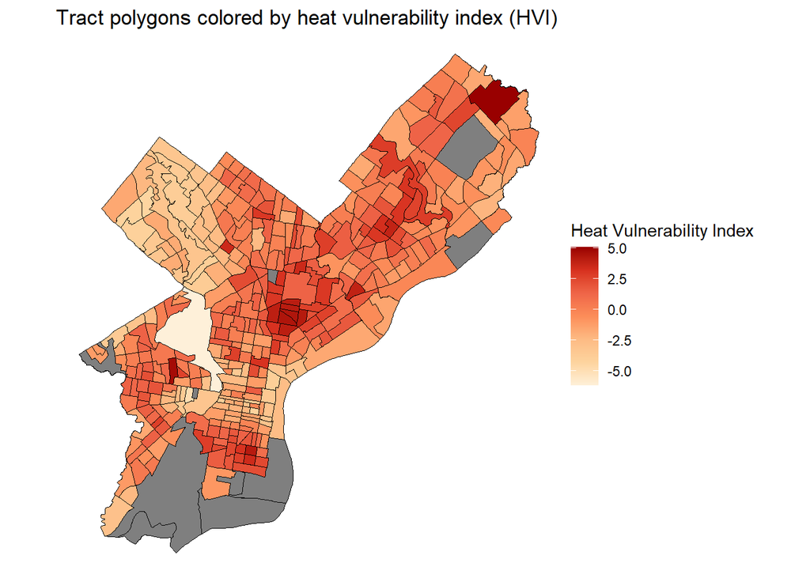

```r
heat_map <- ggplot () +
      theme_void() +
      geom_sf(data = sf.heat, aes(fill = HVI_SCORE), colour = "black", size=0.1) +
  ggtitle("Tract polygons colored by heat vulnerability index (HVI)") +
      scale_fill_distiller(type = "seq", palette = "OrRd", direction = 1, name= "Heat Vulnerability Index")
heat_map
```

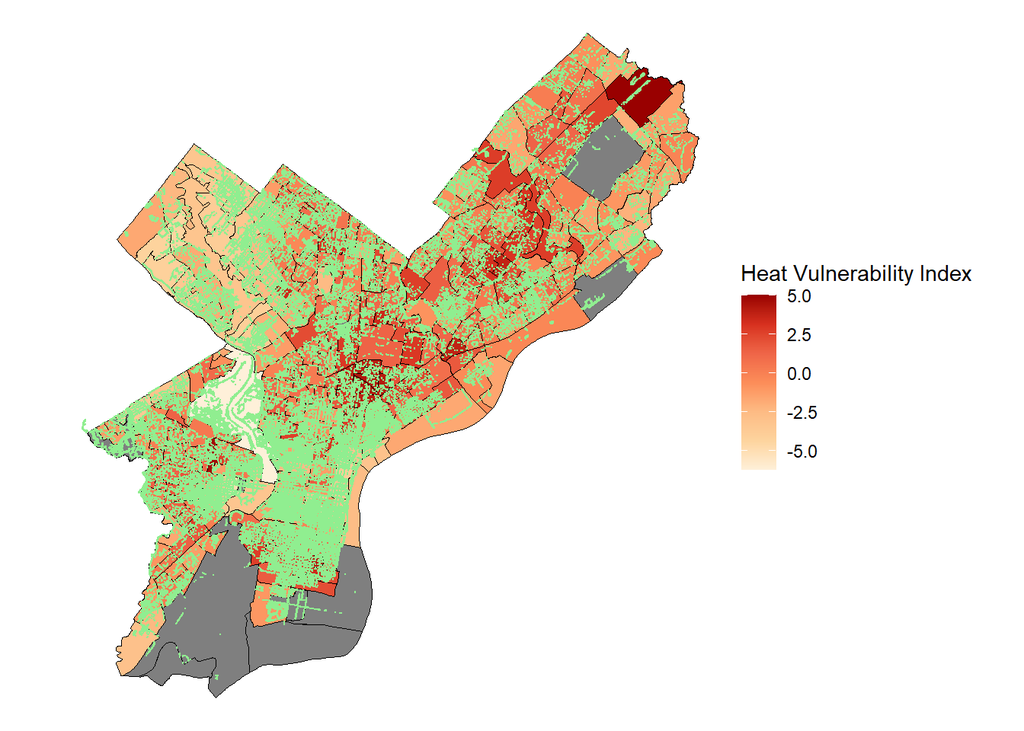

```r
heattree_map <- ggplot () +
      theme_void() +
      geom_sf(data = sf.heat, aes(fill = HVI_SCORE), colour = "black", size=0.1) +
      scale_fill_distiller(type = "seq", palette = "OrRd", direction = 1, name= "Heat Vulnerability Index") +
      geom_sf(data = sf.tree, size=0.005, color = "lightgreen")
heattree_map
```

This isn’t a very informative map - it looks like there are lots of trees across the city, and plotting them obscures the HVI. A better tactic might be to calculate the number of trees per census tract, then map that side-by-side with a map of HVI.

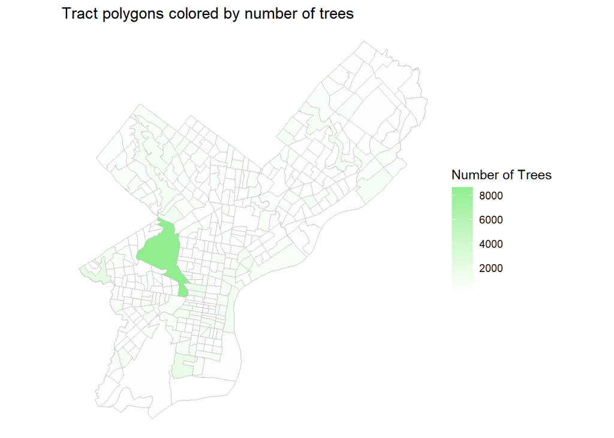

```r
#Append a census tract to each tree
df.trees <- st_join(sf.tree, sf.heat, join = st_within) #Find intersections

#Count number of trees per census tract and append to heat data
sf.heat <- left_join(sf.heat,
          plyr::count(df.trees$GEOID10)%>%
            rename("GEOID10" = 'x', "TreeNumber"='freq'))%>%
  mutate(TreeNumber = ifelse(is.na(TreeNumber), 0, TreeNumber))
tree_map <- ggplot() +
  theme_void() +
  geom_sf(data = sf.heat, aes(fill=TreeNumber), colour = "gray", size = 0.1) +
  ggtitle("Tract polygons colored by number of trees")+
  scale_fill_continuous(low = "white", high = "lightgreen", name = "Number of Trees")
tree_map
```

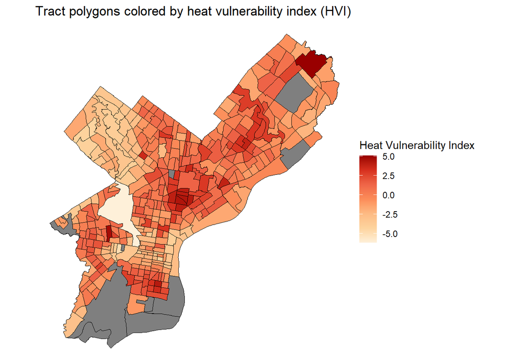

```r
#It looks like the presence of a large park in our map area has messed with our scaling. Let's set custom limits.
max_tree_col <- quantile(sf.heat$TreeNumber, .98, na.rm = T)
min_tree_col <- quantile(sf.heat$TreeNumber, 0, na.rm = T)

tree_map2 <- ggplot() +
  theme_void() +
  geom_sf(data = sf.heat, aes(fill=TreeNumber), colour = "gray", size = 0.1) +
  ggtitle("Tract polygons colored by number of trees") +
  scale_fill_continuous(low = "white", high = "lightgreen", name = "Number of Trees", limits = c(min_tree_col, max_tree_col))


par(mfrow=c(1,2))
heat_map
```

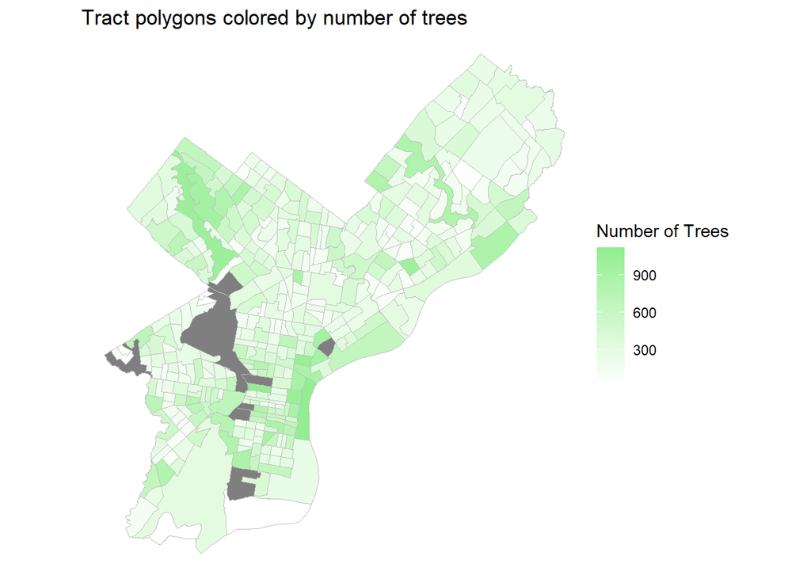

```r
tree_map2
```

It looks like there might be a relationship between number of trees in a census block and HVI. Does this relationship show up if we run a linear regression? (Caveat - this assumes that all of the assumptions of a linear model hold, which I’m not going to address in this example.)

```r
summary(lm(HVI_SCORE ~ TreeNumber, data=sf.heat))
```

```
##
## Call:
## lm(formula = HVI_SCORE ~ TreeNumber, data = sf.heat)
##
## Residuals:
##     Min      1Q  Median      3Q     Max
## -4.7515 -1.3996  0.0323  1.2977  4.9278
##
## Coefficients:
##               Estimate Std. Error t value Pr(>|t|)
## (Intercept)  0.5152158  0.1241714   4.149 4.14e-05 ***
## TreeNumber  -0.0012899  0.0001965  -6.564 1.76e-10 ***
## ---
## Signif. codes:  0 '***' 0.001 '**' 0.01 '*' 0.05 '.' 0.1 ' ' 1
##
## Residual standard error: 1.892 on 372 degrees of freedom
##   (10 observations deleted due to missingness)
## Multiple R-squared:  0.1038, Adjusted R-squared:  0.1014
## F-statistic: 43.09 on 1 and 372 DF,  p-value: 1.76e-10
```